# RBBS - 9 Relational Data - Part I

# Data - Long format

```r
# Data / Reports Wide Format
# glimpse(df_report_long)
# Rows: 19,059,582
# Columns: 10
# $ fiscal_year              <int> 2021, 2021, 2021, 2021, 2021, 2~
# $ period                   <chr> "FY21Q1", "FY21Q2", "FY21Q3", "~
# $ orgunituid               <chr> "SSqrxMy7RHB", "SSqrxMy7RHB", "~
# $ mech_code                <chr> "18675", "18675", "18675", "186~
# $ indicator                <chr> "CXCA_SCRN", "CXCA_SCRN", "CXCA~
# $ disaggregate             <chr> "Total Numerator", "Total Numer~
# $ standardizeddisaggregate <chr> "Total Numerator", "Total Numer~
# $ categoryoptioncomboname  <chr> "default", "default", "default"~
# $ value_type               <chr> "qtr_results", "qtr_results", "~
# $ value                    <dbl> NA, NA, NA, NA, NA, 3689, NA, 1~
```

# Relationship Keys

How are the MSDs put together? How are the different data sets related to one another?

Relational data rely on `keys`, uniquely identifiable variable, to connect tables. There are 2 types of keys, a `Primary Key` (uniquely identify a record in a table) and `Foreign Key` (uniquely identify a record in another table)

Keys can be used to test the uniqueness of records / observation in a table.

Based on the image below, how will you draw similar diagram for your MSD?

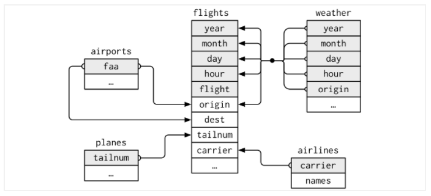

ERD - Entity Relationship Diagram

# Duplicates, Uniqueness checks

The best way to check duplicates / uniqueness is to count the number of records by key. In R / Tidyverse world you will use `dplyr::count` function.

```r
df_orgs %>%
  count(sitename) %>%
  filter(n > 1)
```

# Duplicates, Uniqueness checks - Sitename

```r
df_orgs %>%
  count(operatingunit, countryname,
        psnu, community, sitetype, sitename) %>%
  filter(n > 1)
```

# Duplicates, Uniqueness checks - Orgunituid

```r
df_orgs %>%
  count(operatingunit, countryname,
        psnu, community, sitetype, sitename, orgunituid) %>%
  filter(n > 1)
```

# Combining data sets - Joins

How can we combine related data set?

Data sets are related when the have 1 or multiple variables in common and they can be combined using the common variables. These variables are usually Primary and Foreign Keys of their respective tables.

Tables are combined using `Join`, and one can only combine 2 tables at the time.

There are multiple type of join:

`Inner Join` matches pairs of observations whenever their keys are equal `Outer Join` keeps observations that appear in at least one of the table. There are 3 types of outer joins: left, right and full joins. `Left Join` keeps all the observations in the left side table `Right Join` Keeps all the observations in right side table `Full Join` keeps all the observations in both tables

# Combining data sets - Joins Venn Diagram

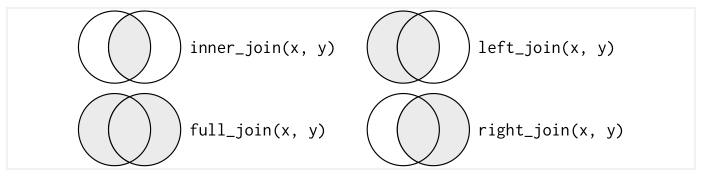

Joins Venn Diagram

# Combining data sets - Joins

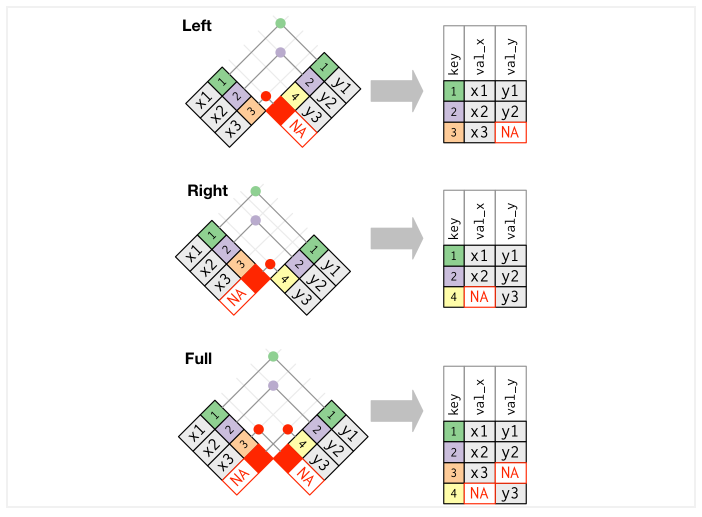

Joins Graphics

# Practice time - inner join

```r
df_report_long %>%
  filter(fiscal_year == 2022,
         value_type == "results",
         str_detect(mech_code, "^81")) %>%
  inner_join(x = .,
             y = df_mechs %>% filter(mech_code == 81862),
             by = "mech_code")
```

# Practice time - left join

```r
df_report_long %>%
  filter(fiscal_year == 2022,
         value_type == "results",
         str_detect(mech_code, "^81")) %>%
  left_join(x = .,
            y = df_orgs,
            by = "orgunituid")
```

# Practice time - right join

```r
df_report_long %>%
  filter(fiscal_year == 2022,
         value_type == "results",
         str_detect(mech_code, "^81")) %>%
  right_join(x = .,
             y = df_orgs,
             by = "orgunituid")
```

# Practice time - full join

```r
df_report_long %>%
  filter(fiscal_year == 2022,
         value_type == "results",
         str_detect(mech_code, "^81")) %>%
  full_join(x = .,
            y = df_orgs %>% filter(psnu == "Akwa Ibom"),
            by = "orgunituid")
```